# Viking Rune-stone

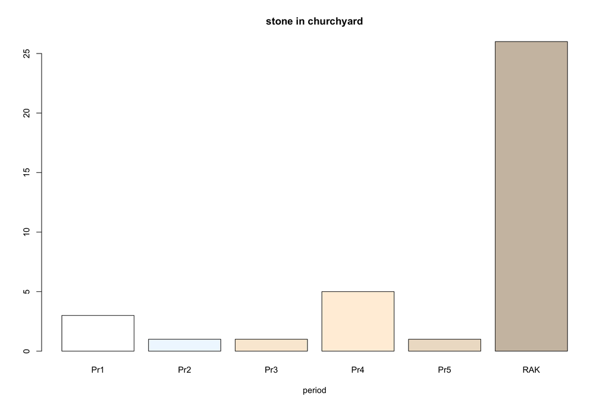

Before the Christianity spread to Viking, we knew that the rune-stone disturbed in the church and cemetery. However, when it moved to the end of Viking period, most of rune-stone were gathered in the church. The centre of rune-stone had moved to the church. We doubted that this move was associated with the spread of Christianity.

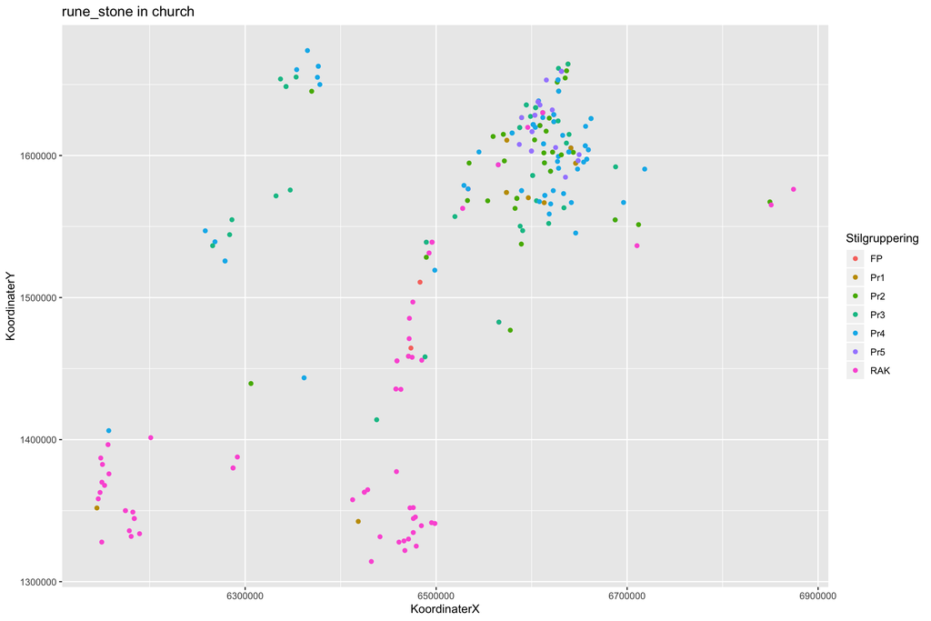

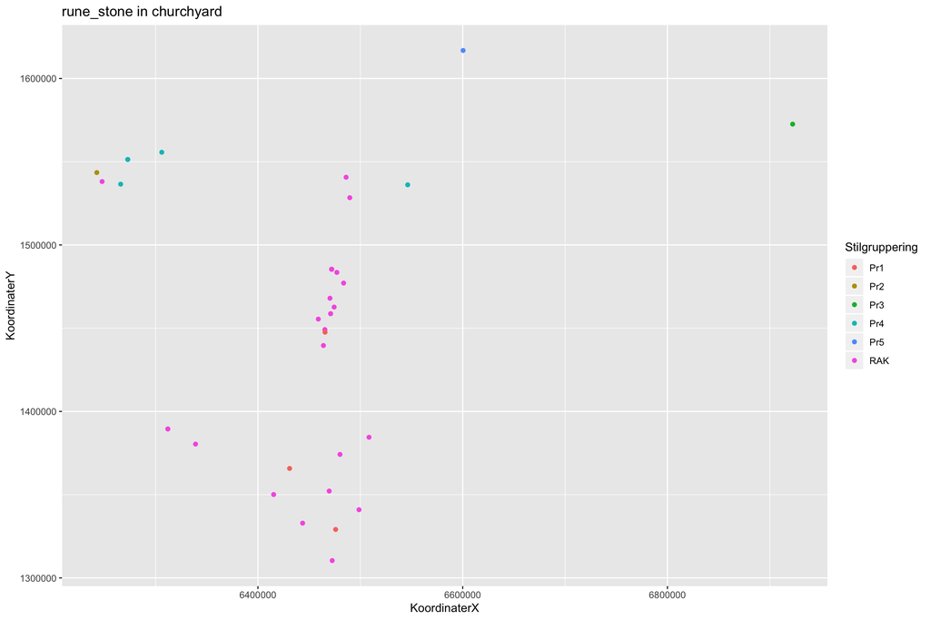

## 2.2 Summary

The Christianity might spread to Viking even earlier than we expect. However, becuase the some of the rune-stone had been damage, and some have been destoried. It’s impossible to find the exactly history of Viking. However, we can still use the data we have and to make hypothesis.